# Partie 1 : Analyse exploratoire des données (201902_fordgobike-tripdata)

# Introduction

*La visualisation de données est une compétence importante qui est utilisée dans de nombreuses parties du processus d'analyse de données.*

- La visualisation de données exploratoire se produit généralement pendant et après le processus de traitement des données, et constitue la principale méthode qu'on utilise pour comprendre les modèles et les relations présents des données.
- Les techniques de visualisation des données explicatives sont utilisées après avoir généré des conclusions, et sont utilisées pour aider à communiquer les résultats aux autres.

*Ce Projet sera axé sur l'analyse exploratoire des données. Le jeu de donnée utilisé vient du système "Ford GoBike". Cet ensemble de données comprend des informations sur les trajets individuels effectués dans un système de partage de vélos couvrant la grande région de la baie de San Francisco.*

```python
# Importer les bibliothèques necessaires Pandas, Numpy, Matplotlib, Seaborn,

import numpy as np
import pandas as pd
import matplotlib.pyplot as plt
import seaborn as sb

%matplotlib inline
```

```python
# Charger le fichier csv "201902_fordgobike-tripdata"

df = pd.read_csv('201902_fordgobike-tripdata.csv')

df.tail(3) # Lire les 3 dernieres lignes du dataframe
```

|  | duration_sec | start_time | end_time | start_station_id | start_station_name | start_station_latitude | start_station_longitude | end_station_id | end_station_name | end_station_latitude | end_station_longitude | bike_id | user_type | member_birth_year | member_gender | bike_share_for_all_trip |
| --- | --- | --- | --- | --- | --- | --- | --- | --- | --- | --- | --- | --- | --- | --- | --- | --- |
| 183409 | 141 | 2019-02-01 00:06:05.5490 | 2019-02-01 00:08:27.2200 | 278.0 | The Alameda at Bush St | 37.331932 | -121.904888 | 277.0 | Morrison Ave at Julian St | 37.333658 | -121.908586 | 3824 | Subscriber | 1990.0 | Male | Yes |
| 183410 | 139 | 2019-02-01 00:05:34.3600 | 2019-02-01 00:07:54.2870 | 220.0 | San Pablo Ave at MLK Jr Way | 37.811351 | -122.273422 | 216.0 | San Pablo Ave at 27th St | 37.817827 | -122.275698 | 5095 | Subscriber | 1988.0 | Male | No |
| 183411 | 271 | 2019-02-01 00:00:20.6360 | 2019-02-01 00:04:52.0580 | 24.0 | Spear St at Folsom St | 37.789677 | -122.390428 | 37.0 | 2nd St at Folsom St | 37.785000 | -122.395936 | 1057 | Subscriber | 1989.0 | Male | No |

*Toutes ses informations me permettent d'avoir une idée sur le nombre de ligne, de colonnes des données. Ainsi je pourrai determiner les types de données et avoir une idée generale sur le dataset a traiter. Je peux maintenant continuer mon analyse.*

## Evaluation de Données

*Je suis maintenant au niveau de l'évaluation des données. Je ferai une evaluation visuelle et programmatique pour les problèmes de qualité et d'ordre. Tout ceci se fera avec une documentation pour facliter la comprehension*

```python
# j'affiche la base pour l'evaluer visuellement

df
```

|  | duration_sec | start_time | end_time | start_station_id | start_station_name | start_station_latitude | start_station_longitude | end_station_id | end_station_name | end_station_latitude | end_station_longitude | bike_id | user_type | member_birth_year | member_gender | bike_share_for_all_trip |
| --- | --- | --- | --- | --- | --- | --- | --- | --- | --- | --- | --- | --- | --- | --- | --- | --- |
| 0 | 52185 | 2019-02-28 17:32:10.1450 | 2019-03-01 08:01:55.9750 | 21.0 | Montgomery St BART Station (Market St at 2nd St) | 37.789625 | -122.400811 | 13.0 | Commercial St at Montgomery St | 37.794231 | -122.402923 | 4902 | Customer | 1984.0 | Male | No |
| 1 | 42521 | 2019-02-28 18:53:21.7890 | 2019-03-01 06:42:03.0560 | 23.0 | The Embarcadero at Steuart St | 37.791464 | -122.391034 | 81.0 | Berry St at 4th St | 37.775880 | -122.393170 | 2535 | Customer | NaN | NaN | No |
| 2 | 61854 | 2019-02-28 12:13:13.2180 | 2019-03-01 05:24:08.1460 | 86.0 | Market St at Dolores St | 37.769305 | -122.426826 | 3.0 | Powell St BART Station (Market St at 4th St) | 37.786375 | -122.404904 | 5905 | Customer | 1972.0 | Male | No |
| 3 | 36490 | 2019-02-28 17:54:26.0100 | 2019-03-01 04:02:36.8420 | 375.0 | Grove St at Masonic Ave | 37.774836 | -122.446546 | 70.0 | Central Ave at Fell St | 37.773311 | -122.444293 | 6638 | Subscriber | 1989.0 | Other | No |
| 4 | 1585 | 2019-02-28 23:54:18.5490 | 2019-03-01 00:20:44.0740 | 7.0 | Frank H Ogawa Plaza | 37.804562 | -122.271738 | 222.0 | 10th Ave at E 15th St | 37.792714 | -122.248780 | 4898 | Subscriber | 1974.0 | Male | Yes |
| ... | ... | ... | ... | ... | ... | ... | ... | ... | ... | ... | ... | ... | ... | ... | ... | ... |
| 183407 | 480 | 2019-02-01 00:04:49.7240 | 2019-02-01 00:12:50.0340 | 27.0 | Beale St at Harrison St | 37.788059 | -122.391865 | 324.0 | Union Square (Powell St at Post St) | 37.788300 | -122.408531 | 4832 | Subscriber | 1996.0 | Male | No |
| 183408 | 313 | 2019-02-01 00:05:34.7440 | 2019-02-01 00:10:48.5020 | 21.0 | Montgomery St BART Station (Market St at 2nd St) | 37.789625 | -122.400811 | 66.0 | 3rd St at Townsend St | 37.778742 | -122.392741 | 4960 | Subscriber | 1984.0 | Male | No |
| 183409 | 141 | 2019-02-01 00:06:05.5490 | 2019-02-01 00:08:27.2200 | 278.0 | The Alameda at Bush St | 37.331932 | -121.904888 | 277.0 | Morrison Ave at Julian St | 37.333658 | -121.908586 | 3824 | Subscriber | 1990.0 | Male | Yes |
| 183410 | 139 | 2019-02-01 00:05:34.3600 | 2019-02-01 00:07:54.2870 | 220.0 | San Pablo Ave at MLK Jr Way | 37.811351 | -122.273422 | 216.0 | San Pablo Ave at 27th St | 37.817827 | -122.275698 | 5095 | Subscriber | 1988.0 | Male | No |
| 183411 | 271 | 2019-02-01 00:00:20.6360 | 2019-02-01 00:04:52.0580 | 24.0 | Spear St at Folsom St | 37.789677 | -122.390428 | 37.0 | 2nd St at Folsom St | 37.785000 | -122.395936 | 1057 | Subscriber | 1989.0 | Male | No |

183412 rows × 16 columns

```python
# Afficher 5 entrees de la base pour avoir des informations.

df.sample(5)
```

|  | duration_sec | start_time | end_time | start_station_id | start_station_name | start_station_latitude | start_station_longitude | end_station_id | end_station_name | end_station_latitude | end_station_longitude | bike_id | user_type | member_birth_year | member_gender | bike_share_for_all_trip |
| --- | --- | --- | --- | --- | --- | --- | --- | --- | --- | --- | --- | --- | --- | --- | --- | --- |
| 56230 | 712 | 2019-02-21 09:08:06.1010 | 2019-02-21 09:19:58.3070 | 365.0 | Turk St at Fillmore St | 37.780450 | -122.431946 | 3.0 | Powell St BART Station (Market St at 4th St) | 37.786375 | -122.404904 | 6501 | Subscriber | 1995.0 | Male | No |
| 570 | 477 | 2019-02-28 21:00:51.7720 | 2019-02-28 21:08:49.5700 | 281.0 | 9th St at San Fernando St | 37.338395 | -121.880797 | 296.0 | 5th St at Virginia St | 37.325998 | -121.877120 | 5708 | Subscriber | 1992.0 | Male | Yes |
| 72813 | 296 | 2019-02-19 15:40:58.7460 | 2019-02-19 15:45:55.3400 | 61.0 | Howard St at 8th St | 37.776513 | -122.411306 | 100.0 | Bryant St at 15th St | 37.767100 | -122.410662 | 6291 | Customer | NaN | NaN | No |
| 114031 | 741 | 2019-02-12 10:08:15.0480 | 2019-02-12 10:20:36.7670 | 77.0 | 11th St at Natoma St | 37.773507 | -122.416040 | 21.0 | Montgomery St BART Station (Market St at 2nd St) | 37.789625 | -122.400811 | 4780 | Subscriber | 1982.0 | Male | No |
| 20803 | 867 | 2019-02-26 10:29:50.6970 | 2019-02-26 10:44:18.5690 | 339.0 | Jackson St at 11th St | 37.800002 | -122.266438 | 178.0 | Broadway at 30th St | 37.819381 | -122.261928 | 4642 | Subscriber | 1990.0 | Male | No |

*Mes differentes actions ci dessus effectuer permettent de faire une evaluation visuelle de la base. je pourrai maintenant faire une evaluation programmatique de cette derniere*

```python
# J'affiche les informations relatives à la base de données de facon generale

df.info()
```

```
<class 'pandas.core.frame.DataFrame'>
RangeIndex: 183412 entries, 0 to 183411
Data columns (total 16 columns):
 #   Column                   Non-Null Count   Dtype
---  ------                   --------------   -----
 0   duration_sec             183412 non-null  int64
 1   start_time               183412 non-null  object
 2   end_time                 183412 non-null  object
 3   start_station_id         183215 non-null  float64
 4   start_station_name       183215 non-null  object
 5   start_station_latitude   183412 non-null  float64
 6   start_station_longitude  183412 non-null  float64
 7   end_station_id           183215 non-null  float64
 8   end_station_name         183215 non-null  object
 9   end_station_latitude     183412 non-null  float64
 10  end_station_longitude    183412 non-null  float64
 11  bike_id                  183412 non-null  int64
 12  user_type                183412 non-null  object
 13  member_birth_year        175147 non-null  float64
 14  member_gender            175147 non-null  object
 15  bike_share_for_all_trip  183412 non-null  object
dtypes: float64(7), int64(2), object(7)
memory usage: 22.4+ MB
```

```python
# Je cherche le nombre de valeur manquante pour chaque colonne.

df.isna().sum()
```

```
duration_sec                  0
start_time                    0
end_time                      0
start_station_id            197
start_station_name          197
start_station_latitude        0
start_station_longitude       0
end_station_id              197
end_station_name            197
end_station_latitude          0
end_station_longitude         0
bike_id                       0
user_type                     0
member_birth_year          8265
member_gender              8265
bike_share_for_all_trip       0
dtype: int64
```

*Remarquons que nous avons des valeurs manquantes dans la dataframe df notamment au niveau de :*

- start_station_id (197)
- start_station_name (197)
- end_station_id (197)
- end_station_name (197)
- member_birth_year (8265)
- member_gender (8265)

```python
# Recherchons la presence de doublons dans ce jeu de donnée

df.duplicated().sum()
```

```
0
```

*Nous pouvons donc en deduire, qu'il y a pas de doublons de données dans la base*

```python
# Description de ma table avec une fonction "fdescription"

def fdescription(): # je defini une fonction nommé fdescription
    for col in df:
        print(df[col].describe()) # Le resultat qu'il faut afficher
```

```python
# J'appelle la fonction fdescription pour m'afficher le resultat obtenu.

fdescription()
```

```
count    183412.000000
mean        726.078435
std        1794.389780
min          61.000000
25%         325.000000
50%         514.000000
75%         796.000000
max       85444.000000
Name: duration_sec, dtype: float64
count                       183412
unique                      183401
top       2019-02-25 08:52:07.5820
freq                             2
Name: start_time, dtype: object
count                       183412
unique                      183397
top       2019-02-11 08:03:22.6020
freq                             2
Name: end_time, dtype: object
count    183215.000000
mean        138.590427
std         111.778864
min           3.000000
25%          47.000000
50%         104.000000
75%         239.000000
max         398.000000
Name: start_station_id, dtype: float64
count                   183215
unique                     329
top       Market St at 10th St
freq                      3904
Name: start_station_name, dtype: object
count    183412.000000
mean         37.771223
std           0.099581
min          37.317298
25%          37.770083
50%          37.780760
75%          37.797280
```

[output cut: 61 more lines]

```
25%        1980.000000
50%        1987.000000
75%        1992.000000
max        2001.000000
Name: member_birth_year, dtype: float64
count     175147
unique         3
top         Male
freq      130651
Name: member_gender, dtype: object
count     183412
unique         2
top           No
freq      166053
Name: bike_share_for_all_trip, dtype: object
```

*Je viens d'effectuer mon evaluation sur l'ensemble de données disponible. Grace à cela je vais maintenant determiner quelques Problemes de Qualités et de Rangement.*

## Problemes de Qualité

1. La colonne member_gender est dans un type de donnée inapproprié.
2. Nous n'avons pas besoin des colonnes qui ne sont pas pertinentes pour l'analyse (start_station_latitude, start_station_longitude, end_station_latitude, end_station_longitude)
3. start_time et end_time ne sont pas dans le bon format de type de données
4. user_type n'est pas dans le bon format de type de données
5. Nous avons des valeurs manquantes dans la base de donnée

## Probleme de Rangement

1. Aucun

*Nous pouvons maintenant trouver une solution aux problemes enumerer en passant à la partie nettoyage de données*

# Nettoyage de Données

```python
# Copies des données originales

df_nouv = df.copy()
```

*Je vais resoudre les PROBLEMES DE QUALITES identifiés plus haut.*

#### Probleme #1 : La colonne member_gender est dans un type de donnée inapproprié.

##### Definir : Convertir la colonne member_gender en type 'catégory'

##### Code

```python
df_nouv['member_gender'] = df_nouv['member_gender'].astype('category')
```

##### Test

```python
df_nouv.info()
```

```
<class 'pandas.core.frame.DataFrame'>
RangeIndex: 183412 entries, 0 to 183411
Data columns (total 16 columns):
 #   Column                   Non-Null Count   Dtype
---  ------                   --------------   -----
 0   duration_sec             183412 non-null  int64
 1   start_time               183412 non-null  object
 2   end_time                 183412 non-null  object
 3   start_station_id         183215 non-null  float64
 4   start_station_name       183215 non-null  object
 5   start_station_latitude   183412 non-null  float64
 6   start_station_longitude  183412 non-null  float64
 7   end_station_id           183215 non-null  float64
 8   end_station_name         183215 non-null  object
 9   end_station_latitude     183412 non-null  float64
 10  end_station_longitude    183412 non-null  float64
 11  bike_id                  183412 non-null  int64
 12  user_type                183412 non-null  object
 13  member_birth_year        175147 non-null  float64
 14  member_gender            175147 non-null  category
 15  bike_share_for_all_trip  183412 non-null  object
dtypes: category(1), float64(7), int64(2), object(6)
memory usage: 21.2+ MB
```

##### Code

```python
df_nouv.drop(['start_station_latitude', 'start_station_longitude', 'end_station_latitude', 'end_station_longitude'], axis=1, inplace=True)
```

##### Test

```python
df_nouv.info()
```

```
<class 'pandas.core.frame.DataFrame'>
RangeIndex: 183412 entries, 0 to 183411
Data columns (total 12 columns):
 #   Column                   Non-Null Count   Dtype
---  ------                   --------------   -----
 0   duration_sec             183412 non-null  int64
 1   start_time               183412 non-null  object
 2   end_time                 183412 non-null  object
 3   start_station_id         183215 non-null  float64
 4   start_station_name       183215 non-null  object
 5   end_station_id           183215 non-null  float64
 6   end_station_name         183215 non-null  object
 7   bike_id                  183412 non-null  int64
 8   user_type                183412 non-null  object
 9   member_birth_year        175147 non-null  float64
 10  member_gender            175147 non-null  category
 11  bike_share_for_all_trip  183412 non-null  object
dtypes: category(1), float64(3), int64(2), object(6)
memory usage: 15.6+ MB
```

#### Probleme #3 : start_time et end_time ne sont pas dans le bon format de type de données

##### Definir : Convertir en datetime les colonnes start_time et end_time.

##### Code

```python
df_nouv.start_time = pd.to_datetime(df_nouv.start_time)
```

```python
df_nouv.end_time = pd.to_datetime(df_nouv.end_time)
```

##### Test

```python
df_nouv.info()
```

```
<class 'pandas.core.frame.DataFrame'>
RangeIndex: 183412 entries, 0 to 183411
Data columns (total 12 columns):
 #   Column                   Non-Null Count   Dtype
---  ------                   --------------   -----
 0   duration_sec             183412 non-null  int64
 1   start_time               183412 non-null  datetime64[ns]
 2   end_time                 183412 non-null  datetime64[ns]
 3   start_station_id         183215 non-null  float64
 4   start_station_name       183215 non-null  object
 5   end_station_id           183215 non-null  float64
 6   end_station_name         183215 non-null  object
 7   bike_id                  183412 non-null  int64
 8   user_type                183412 non-null  object
 9   member_birth_year        175147 non-null  float64
 10  member_gender            175147 non-null  category
 11  bike_share_for_all_trip  183412 non-null  object
dtypes: category(1), datetime64[ns](2), float64(3), int64(2), object(4)
memory usage: 15.6+ MB
```

#### Probleme #4 : user_type n'est pas dans le bon format de type de données

##### Definir : Convertir user_type en type category

##### Code

```python
df_nouv['user_type'] = df_nouv['user_type'].astype('category')
```

##### Test

```python
df_nouv.info()
```

```
<class 'pandas.core.frame.DataFrame'>
RangeIndex: 183412 entries, 0 to 183411
Data columns (total 12 columns):
 #   Column                   Non-Null Count   Dtype
---  ------                   --------------   -----
 0   duration_sec             183412 non-null  int64
 1   start_time               183412 non-null  datetime64[ns]
 2   end_time                 183412 non-null  datetime64[ns]
 3   start_station_id         183215 non-null  float64
 4   start_station_name       183215 non-null  object
 5   end_station_id           183215 non-null  float64
 6   end_station_name         183215 non-null  object
 7   bike_id                  183412 non-null  int64
 8   user_type                183412 non-null  category
 9   member_birth_year        175147 non-null  float64
 10  member_gender            175147 non-null  category
 11  bike_share_for_all_trip  183412 non-null  object
dtypes: category(2), datetime64[ns](2), float64(3), int64(2), object(3)
memory usage: 14.3+ MB
```

#### Probleme #5 : Nous avons des valeurs manquantes dans la base de donnée

##### Definir : Supprimer les valeurs manquantes dans le dataset

##### Code

```python
df_nouv.dropna(inplace=True)
```

##### Test

```python
df_nouv.info()
```

```
<class 'pandas.core.frame.DataFrame'>
Int64Index: 174952 entries, 0 to 183411
Data columns (total 12 columns):
 #   Column                   Non-Null Count   Dtype
---  ------                   --------------   -----
 0   duration_sec             174952 non-null  int64
 1   start_time               174952 non-null  datetime64[ns]
 2   end_time                 174952 non-null  datetime64[ns]
 3   start_station_id         174952 non-null  float64
 4   start_station_name       174952 non-null  object
 5   end_station_id           174952 non-null  float64
 6   end_station_name         174952 non-null  object
 7   bike_id                  174952 non-null  int64
 8   user_type                174952 non-null  category
 9   member_birth_year        174952 non-null  float64
 10  member_gender            174952 non-null  category
 11  bike_share_for_all_trip  174952 non-null  object
dtypes: category(2), datetime64[ns](2), float64(3), int64(2), object(3)
memory usage: 15.0+ MB
```

### Quelle est la structure du jeu de données ?

- duration_sec
- start_time
- end_time
- start_station_id
- start_station_name
- end_station_id
- end_station_name
- bike_id
- user_type
- member_birth_year
- member_gender
- bike_share_for_all_trip

### Quelle(s) est/sont la/les principale(s) caractéristique(s) d'intérêt dans votre jeu de données ?

- La durée moyenne d'un trajet à vélo dépend-elle du fait qu'un utilisateur soit Abonné ou Client ?
- Quelle est la destination la plus populaire et est-ce qu'elle dépend du type d'utilisateur ?
- Combien de temps dure un trajet moyen ?

### Selon vous, quelles fonctionnalités de l'ensemble de données vous aideront à étayer votre enquête sur les fonctionnalités qui vous intéressent ?

Pour arriver à etayer mon enquete sur les choses qui m'interessent dans le jeu de donnée, j'utiliserai :

- member_gender
- start_time
- end_time
- end_station_name
- end_station_id
- duration_sec
- user_type

*Je viens de determiner les sujets qui seront des priorités lors de mon analyse ainsi je pourrai mieux presenter mes resultats. Cela se fera grace aux explorations Univariées, Bivariées et Multivariées.*

# Exploration Univariée

*Je commencerai par la colonne du genre des differents membre*

### Exploration 1 : Quel est le nombre d'utilisateur par genre des differents membres

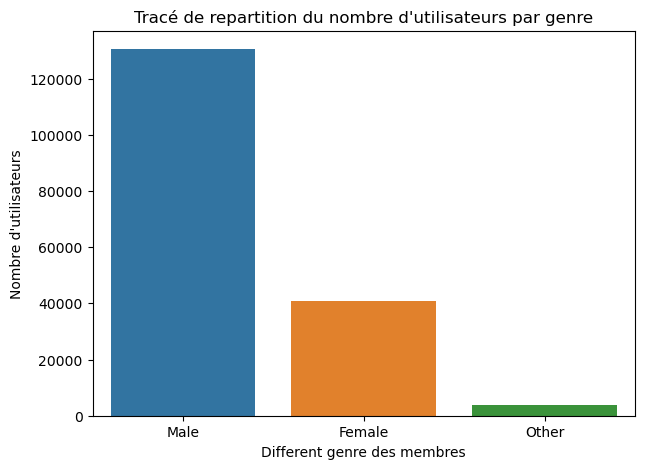

```python
# Nombre d'utilisateurs par genre

ordre_genre = df_nouv['member_gender'].value_counts().index # cree un ordre pour le genre des membres

plt.figure(figsize=[7, 5])

sb.countplot(data = df_nouv, x = 'member_gender', order=ordre_genre)

plt.title("Tracé de repartition du nombre d'utilisateurs par genre") # Definir le titre, le nom sur l'axe x et y
plt.ylabel("Nombre d'utilisateurs")
plt.xlabel('Different genre des membres');
```

*Les utilisateurs masculins viennent en premier, ensuite nous avons les femmes et les autres utilisateurs à la fin*

### Exploration 2 : Quel est le nombre d'utilisateur par type d'utilisateur

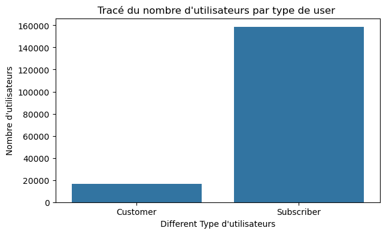

```python
# Nombre d'utilisateurs par type de user

coul_base = sb.color_palette()[0] # Defnir la couleur de base (bleue)

plt.figure(figsize=[7, 4])

sb.countplot(data = df_nouv, x = 'user_type', color = coul_base) # Fonction qui permet de tracé le plot

plt.title("Tracé du nombre d'utilisateurs par type de user ") # Definir le titre, le nom sur l'axe x et y
plt.ylabel("Nombre d'utilisateurs")
plt.xlabel("Different Type d'utilisateurs");
```

*Nous remarquons que les "Abonnés" sont vraiment plus nombreux que les "clients" simples.*

### Exploration 3 : Quel est la liste des 5 meilleures destinations

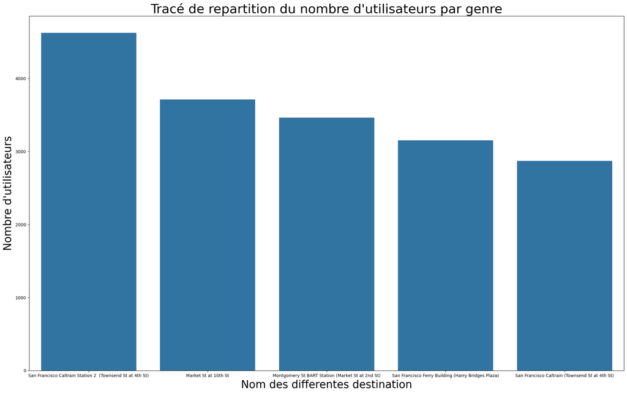

```python
# La liste des 5 meilleurs destinations

ordre_genre = df_nouv['end_station_name'].value_counts().index[:5] # ordre des noms des destination par index

coul_base = sb.color_palette()[0] # Definir la couleur de base

plt.figure(figsize=[25, 15])

sb.countplot(data = df_nouv, x='end_station_name', color=coul_base, order=ordre_genre)

plt.title("Tracé de repartition du nombre d'utilisateurs par genre", fontsize=30) # Definir le titre, le nom sur l'axe x et y
plt.ylabel("Nombre d'utilisateurs", fontsize=25)
plt.xlabel('Nom des differentes destination', fontsize=25);
```

### Exploration 4 : Quel est la liste des 3 lieu de depart les plus populaires

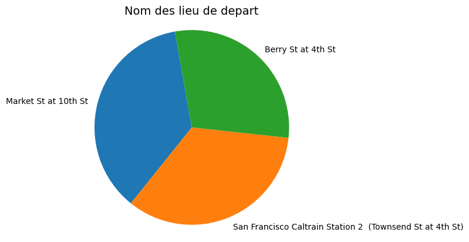

```python
# la liste des 3 lieu de depart les plus populaire

nbre_u = df_nouv['start_station_name'].value_counts()[:3] # variable 'nbre_u' qui recoit la liste des 3 lieu

plt.pie(nbre_u, labels = nbre_u.index, startangle = 100); #
plt.axis('equal');
plt.title('Nom des lieu de depart', fontsize=14);
```

### Exploration 5 : Quel est la durée des trajets par seconde

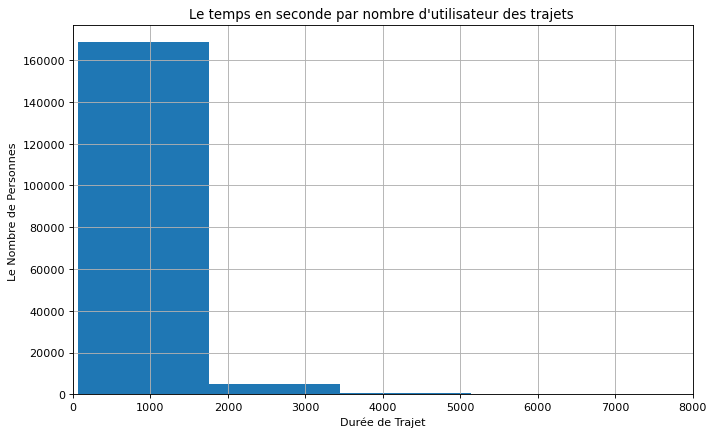

```python
# la durée des trajets par seconde

plt.figure(figsize=(10,6), dpi = 80)
df_nouv['duration_sec'].hist(bins=50)

plt.xlim(0, 8000)
plt.xlabel('Durée de Trajet')
plt.ylabel('Le Nombre de Personnes ')
plt.title("Le temps en seconde par nombre d'utilisateur des trajets ");
```

*Cette visualisation est très difficile à interpréter. Ce n'est pas très utile car les durées sont en secondes. Je vais convertir la durée en minutes pour avoir une meilleure vue*

```python
# Changer la duree en minutes

df_nouv['duration_min'] = df_nouv['duration_sec']/60

df_nouv.duration_min = df_nouv.duration_min.astype('int64')
```

### Exploration 6 : Quel est la durée des trajets par Minute

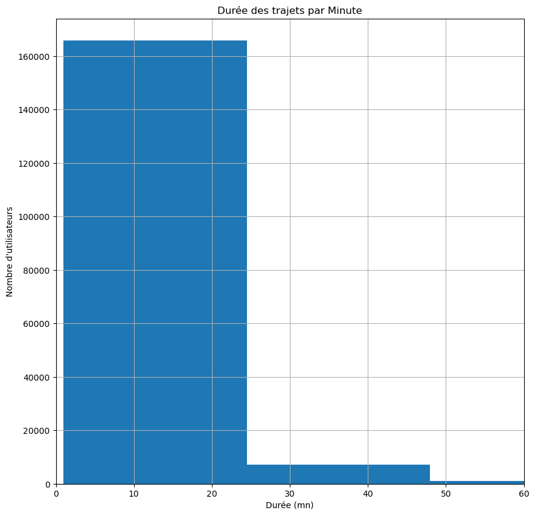

```python
# la durée des trajets par minute

plt.figure(figsize = (10,10))

df_nouv['duration_min'].hist(bins=60)
plt.xlim(0, 60)
plt.xlabel('Durée (mn)')
plt.ylabel("Nombre d'utilisateurs")
plt.title("Durée des trajets par Minute")

plt.show()
```

*Nous avons une visualisation plus explicative de la durée des trajets*

### Exploration 7 : Quel le nombre d'utilisateur par age

```python
# Creer la variable age à partir de l'annee de naissance des utilisateurs

df_nouv['age'] = df_nouv['member_birth_year'].apply(lambda x: 2019 - x)
```

```python
# La description des ages à travers la nouvelle variable

df_nouv['age'].describe()
```

```
count    174952.000000
mean         34.196865
std          10.118731
min          18.000000
25%          27.000000
50%          32.000000
75%          39.000000
max         141.000000
Name: age, dtype: float64
```

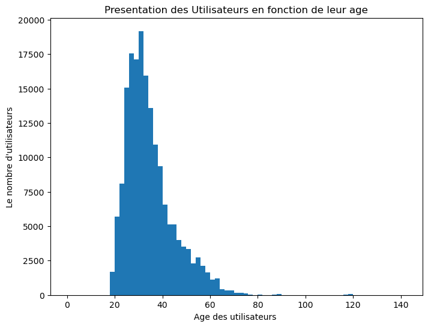

```python
# L'age des differentes personnes utilisant les velos pour les trajets

plt.figure(figsize=(8,6))
bins = np.arange(0, df_nouv['age'].max()+2, 2)

plt.hist(data=df_nouv, x='age', bins=bins)
plt.xlabel('Age des utilisateurs ')
plt.ylabel("Le nombre d'utilisateurs")
plt.title("Presentation des Utilisateurs en fonction de leur age");
```

*Repondons maintenant aux differentes questions concernant nos visualisation effectuées plus haut*

### Discutez de la ou des distributions de vos variables d'intérêt. Y avait-il des points inhabituels ? Avez-vous eu besoin d'effectuer des transformations ?

> Ma première variable d'intérêt est duration_sec. J'ai eu un problème de visualisation avec. Les choses étaient très confuses. Du coup, je dois transformer la durée des trajets de secondes en minutes. Cela m'a donné une visualisation claire et utile. Ma deuxième variable d'intérêt était le type d'utilisateur. Cette variable n'a pas de points inhabituels. L'exploration a clairement montré qu'il y avait plus d'abonnés que de clients.

### Parmi les fonctionnalités que vous avez étudiées, y avait-il des distributions inhabituelles ? Avez-vous effectué des opérations sur les données pour ranger, ajuster ou modifier la forme des données ? Si oui, pourquoi avez-vous fait cela ?

> J'ai dû calculer l'âge des utilisateurs en fonction de leur date d'anniversaire. J'ai ajouté cette nouvelle colonne, l'âge, pour faciliter le travail et donner des données utiles à l'équipe marketing. Deuxièmement, quand j'ai fait les distributions d'âge, j'ai remarqué qu'il y avait des valeurs d'outliners et j'avais des âges qui vont jusqu'à 140 ans. Ce type de valeurs ne peut pas aider à mieux comprendre l'ensemble de données.

## Exploration Bivariée

*Dans cette section, j'étudierai les relations entre les paires de variables de mes données.*

```python
# Liste des variables numeriques et des variables catégoriques

numer_vars = ['age','duration_sec']
cat_vars = ['user_type','member_gender']
```

### Exploration 8 : Quel est la relation entre l'age des membres et la duree en seconde

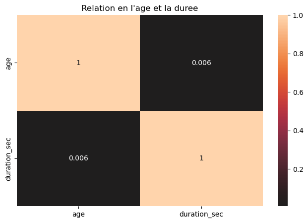

```python
# Correlation entre l'age et la duree en seconde

plt.figure(figsize = [8, 5])
sb.heatmap(df_nouv[numer_vars].corr(), annot = True, center = 0)
plt.title("Relation en l'age et la duree");
```

*Nous avons une representation de la relation entre la duree de trajet en seconde et l'age des utilisateurs. Elle n'est pas vraiment explication mais nous donne une idéé de la relation et des ages*

### Exploration 9 : Comment se presente la répartition de la durée du trajet par type d'utilisateur

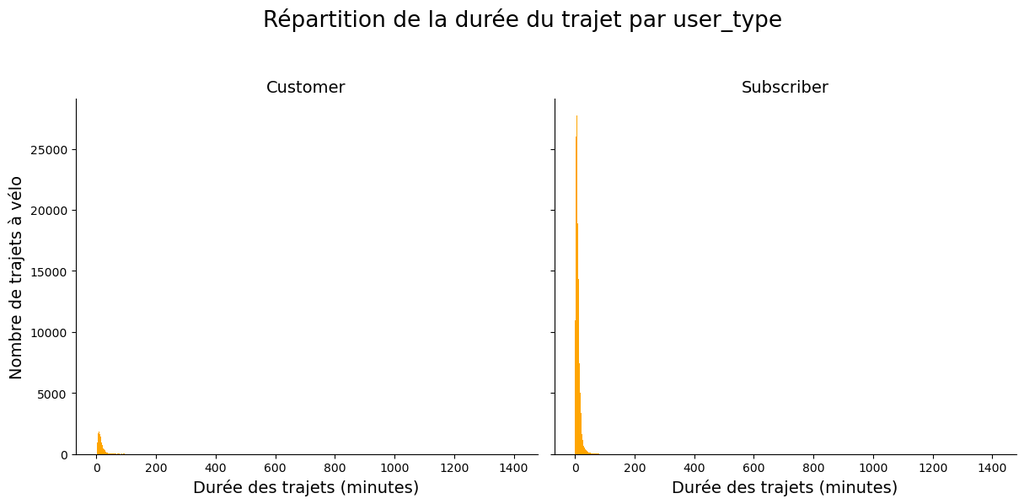

```python
# Répartition de la durée du trajet par user_type'

df_nouv['duration_min'] = df_nouv['duration_sec']/60 # avoir une colonne de temps en minutes qu'en seconde.


g = sb.FacetGrid(data = df_nouv, col = 'user_type', col_wrap = 2, height = 6)
g.map(plt.hist, 'duration_min', bins = np.arange(df_nouv['duration_min'].min(),
                                                 df_nouv['duration_min'].max()+1, 2) , color="Orange")


g.set_ylabels('Nombre de trajets à vélo', size=14)
g.set_xlabels('Durée des trajets (minutes)', size=14)
g.set_titles('{col_name}', size=14);

plt.subplots_adjust(top=0.8)
g.fig.suptitle('Répartition de la durée du trajet par user_type', fontsize=19);
```

*On peut conclure naturellement que le nombre d'abonné est beaucoup plus elevé que le nombre de client et ce par minutes*

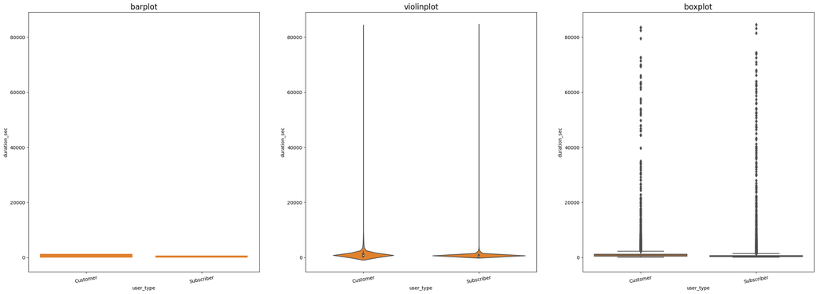

```python
# Je crée un barplot, un violinplot et un boxplot pour analyser la relation entre 'duration_min' du voyage et 'user_type'

plt.figure(figsize = [30, 10])
base_color = sb.color_palette()[1]

# graphe du milieu : violinplot
plt.subplot(1, 3, 2)
ax1 = sb.violinplot(data = df_nouv, x = 'user_type', y = 'duration_sec', color = base_color)
           # en définissant inner = 'quartile' dans le graphique du violon, trois lignes seront tracées dans chaque zone de violon pour les trois quartiles du milieu.
            # La ligne avec des tirets épais indique la médiane, et les deux lignes avec des tirets plus courts de part et d'autre les premier et troisième quartiles.


plt.xticks(rotation = 10)             # inclure la rotation des étiquettes en raison de la petite taille de la sous-parcelle
plt.title('violinplot', fontsize=16)

# graphe du coté gauche: barplot
plt.subplot(1, 3, 1)
sb.barplot(data = df_nouv, x = 'user_type', y = 'duration_sec', color = base_color)
plt.xticks(rotation = 10)
plt.ylim(ax1.get_ylim())              # définir les limites de l'axe y pour qu'elles soient identiques à celles du tracé de gauche
plt.title('barplot', fontsize=16);

# graphe du coté gauche : boxplot
plt.subplot(1, 3, 3)
sb.boxplot(data = df_nouv, x = 'user_type', y = 'duration_sec', color = base_color)
plt.xticks(rotation = 10)
plt.ylim(ax1.get_ylim())              # définir les limites de l'axe y pour qu'elles soient identiques à celles du tracé de gauche
plt.title('boxplot', fontsize=16);
```

### Exploration 11 : Quelle est la durée en seconde par rapport à l'âge de l'utilisateur

```python
# déterminer index-object pour pouvoir presenté la grille à facettes dans l'ordre décroissant de destination

m_moy = df_nouv.groupby('end_station_name').count()
comb_ordre = m_moy.sort_values('duration_sec', ascending = False).index
```

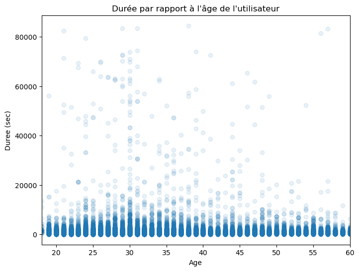

```python
# scatter plot de la durée par rapport à l'age

plt.figure(figsize = [8, 6])
plt.scatter(data = df_nouv, x = 'age', y = 'duration_sec', alpha = 1/10)
plt.xlabel('Age')
plt.xlim(18, 60)
plt.ylabel('Duree (sec)')
plt.title("Durée par rapport à l'âge de l'utilisateur")
plt.show()
```

### Exploration 12 : Quelle est la durée en seconde par rapport au sexe des utilisateur

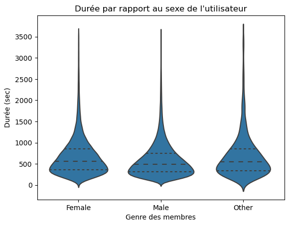

```python
# Presenter les données pour une durée uniquement inférieure à 1 heure (3600 seconde)

df_nouv_durée = df_nouv.query("duration_sec < 3600")

# tracer la relation entre le sexe et la durée

base_color = sb.color_palette()[0]
sb.violinplot(data=df_nouv_durée, x='member_gender', y='duration_sec', color=base_color, inner='quartile')
plt.xlabel('Genre des membres')
plt.ylabel('Durée (sec)')
plt.title("Durée par rapport au sexe de l'utilisateur");
```

### Exploration 13 : Quelle est la durée en seconde par rapport au type d'utilisateur

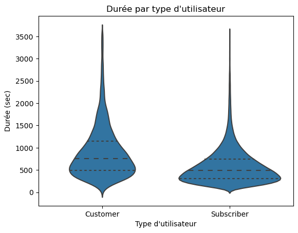

```python
# tracer de la relation entre le type d'utilisateur et la durée

base_color = sb.color_palette()[0]

sb.violinplot(data=df_nouv_durée, x='user_type', y='duration_sec', color=base_color, inner='quartile')
plt.xlabel("Type d'utilisateur")
plt.ylabel('Durée (sec)')
plt.title("Durée par type d'utilisateur");
```

### Exploration 14 : Quelle est la relation entre le sexe du membre et le type d'utilisateur

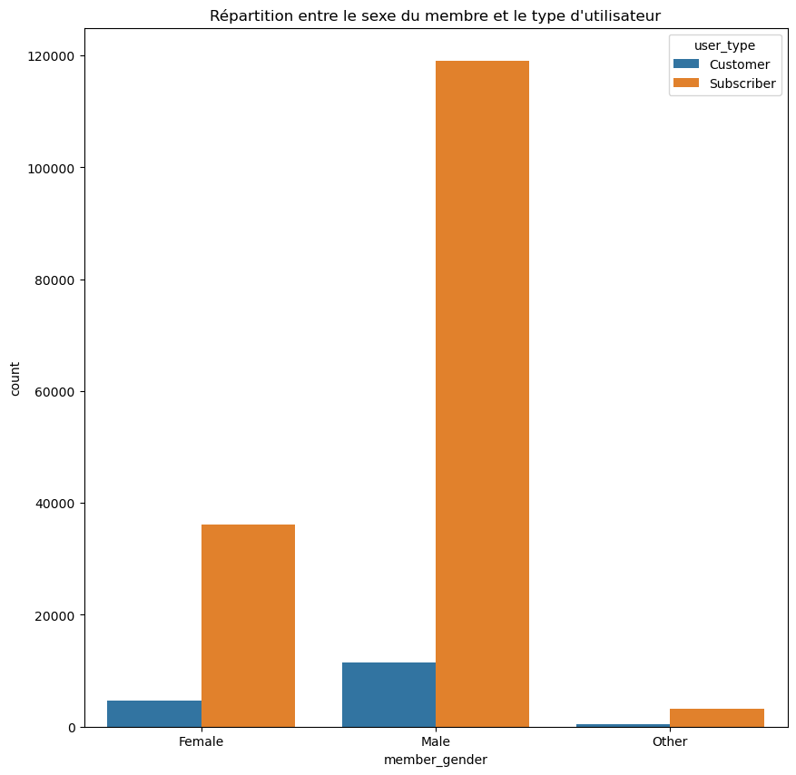

```python
# Code pour visualiser la relation entre le sexe du membre et le type d'utilisateur

plt.figure(figsize = [10, 10]);

sb.countplot(data = df_nouv, x = 'member_gender', hue = 'user_type');

plt.title("Répartition entre le sexe du membre et le type d'utilisateur");
```

### Parlez de certaines des relations que vous avez observées dans cette partie de l'enquête. Comment la ou les caractéristiques d'intérêt ont-elles varié avec d'autres caractéristiques de l'ensemble de données ?

> Mon enquête m'a montré des choses intéressantes. Une de ces découvertes intéressantes est que les Clients sont les personnes qui ont le plus de durée en minutes pour le service de trajet à vélo même si nous avons montré en exploration Univariée qu'il y a plus d'abonnés que de clients. Il s'agit d'une donnée marketing importante qui peut être utilisée par le service afin de savoir où il mettra plus d'efforts.

> Pour la durée, nous avons aussi remarqué que les femelles ont plus de durée que les mâles.

## Exploration Multivariée

*Je vais créer des graphiques de trois variables ou plus pour approfondir mes données.*

### Exploration 15 : Quelle est la relation entre le sexe du membre et le type d'utilisateur

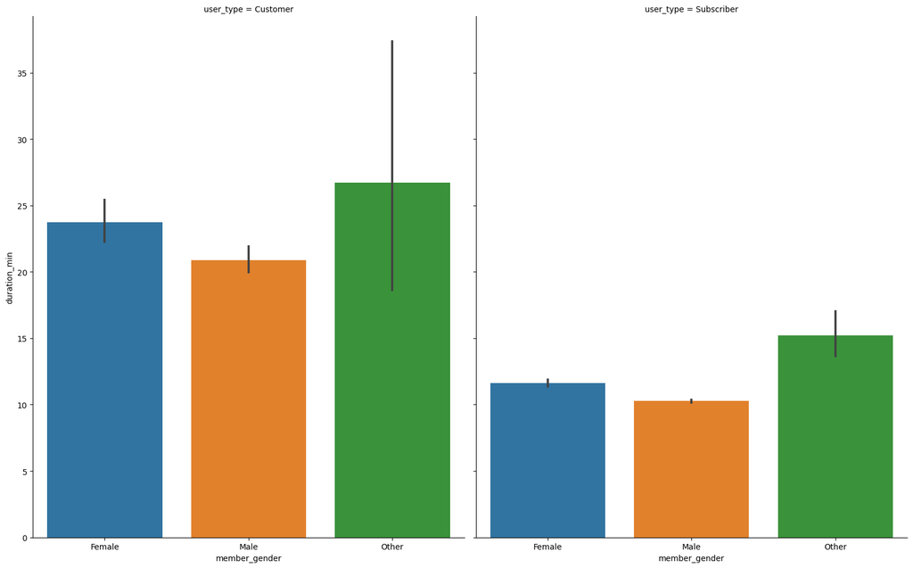

```python
# Code pour connaître la relation entre user_type, la durée en minutes et member_gender

sb.catplot(x = "member_gender", y = "duration_min",
                col = "user_type",
                data = df_nouv, kind = "bar",
                height=10, aspect=.8);
```

*Nous pouvons voir sur la visualisation que pour les clients, les femmes ont plus de durée en minutes que les hommes. La durée moyenne des autres sexes est plus élevée que celle des deux autres. Pour les abonnés le nombre est moindre mais c'est le même constat.*

### Exploration 16 : Quelle est la relation entre les jours de la semaine, la duree en minutes et les type d'utilisateur

```python
# Je vais créé la colonne "start_time_semaine" pour les differents jours de la semaine a partir de "start_time"

df_nouv ['start_time_semaine'] = df_nouv['start_time'].dt.strftime('%A') # Avoir les jours de la semaine

jr_semaine = ['Monday', 'Tuesday', 'Wednesday', 'Thursday', 'Friday', 'Saturday', 'Sunday']
```

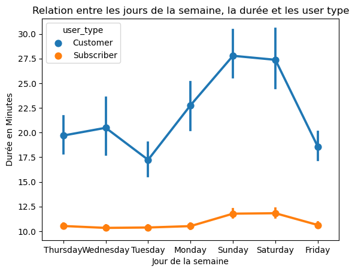

```python
# Code pour explorer la distribution entre start_time_semaine, la durée en minutes et user_type

sb.pointplot(data=df_nouv, x='start_time_semaine', y='duration_min', hue='user_type')

plt.xlabel('Jour de la semaine')
plt.ylabel('Durée en Minutes')
plt.title("Relation entre les jours de la semaine, la durée et les user type");
```

*Nous pouvons voir sur cette visualisation que les abonnés prennent moins de temps tous les jours de la semaine, par rapport aux clients.*

### Exploration 17 : Quelle est la relation entre les jours de la semaine, la duree en minute et du genre des memebres

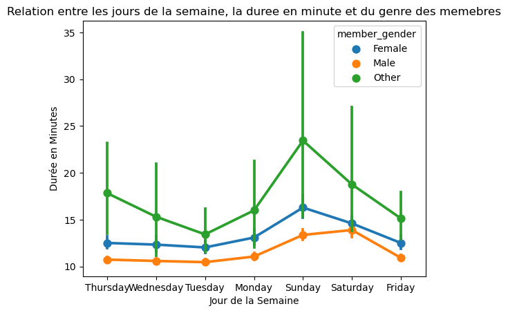

```python
# la relation entre les jours de la semaine, la duree en minute et du genre des memebres

sb.pointplot(data=df_nouv, x='start_time_semaine', y='duration_min', hue='member_gender')

plt.xlabel('Jour de la Semaine')
plt.ylabel('Durée en Minutes')
plt.title("Relation entre les jours de la semaine, la duree en minute et du genre des memebres");
```

*Cette visualisation montre que les hommes prennent moins de temps que les femmes tous les jours de la semaine.*

### Parlez de certaines des relations que vous avez observées dans cette partie de l'enquête. Y a-t-il eu des fonctionnalités qui se sont renforcées en termes d'examen de vos fonctionnalités d'intérêt ?

> Avec cette exploration, j'ai approfondi l'interaction entre la durée et d'autres fonctionnalités telles que le sexe et le type d'utilisateur. Ainsi, j'ai remarqué clairement que les femmes ont plus de durée en minutes que les hommes. La durée moyenne des autres sexes est plus élevée que celle des deux autres. C'est la même chose pour les abonnés et les clients sauf que les numéros pour les clients sont plus que les numéros d'abonnés.

> J'ai aussi remarqué que ma fonctionnalité principale n'a pas de forte corrélation avec d'autres fonctionnalités.

### Y a-t-il eu des interactions intéressantes ou surprenantes entre les fonctionnalités ?

> Une visualisation intéressante a montré que les gens (hommes, femmes et autres sexes) prennent plus de temps pour rouler pendant le week-end.